# UML ASS 5 CLUSTER PCA

Program: Professional Certificate in Data Science,Machine Learning & AI Module: Unsupervised Machine Learning Methods Techniques: K-means Clustering, Principal Component Analysis(PCA)

Instructor: Lumumba W. Victor Email: lumumbavictor172@gmail.com

Dataset: medical_clustering_data.csv Date Issued: April 24, 2026

Student: KIBIDI K. LERENCER Reg no: CDAM/0047/2026

**2.1 Task 1: Data Import and Initial Exploration**

```python
#2.1.1 Load required libraries
# Import and verify all libraries
import pandas as pd
import numpy as np
import matplotlib.pyplot as plt
import seaborn as sns
from scipy import stats
from sklearn.preprocessing import StandardScaler
from sklearn.decomposition import PCA
from sklearn.cluster import KMeans
from sklearn.metrics import silhouette_score, silhouette_samples
from sklearn.impute import SimpleImputer

print("All libraries imported successfully!")
```

```
All libraries imported successfully!
```

```python
#2.1.2a: Import medical_clustering_data.csv

##from google.colab import files
#uploaded = files.upload()

df = pd.read_csv('medical_clustering_data.csv')
```

```python
#2.1.2b: Display first 6 rows

df.head()
```

|  | patient_id | age | sex | bmi | waist_cm | bp_systolic | bp_diastolic | heart_rate | cholesterol_total | cholesterol_hdl | cholesterol_ldl | triglycerides | glucose_fasting | hba1c | crp | smoking_status | alcohol_drinks_week | physical_activity_min_week | risk_score | metabolic_syndrome |
| --- | --- | --- | --- | --- | --- | --- | --- | --- | --- | --- | --- | --- | --- | --- | --- | --- | --- | --- | --- | --- |
| 0 | PT-001 | 59 | Male | 17.3 | 138.8 | 153.0 | 96 | 88 | 154.6 | 54.1 | 60.6 | 83.90 | NaN | 5.56 | 0.20 | Current | 5 | 145.0 | 11.8 | 0 |
| 1 | PT-002 | 37 | Female | 27.6 | 140.0 | 103.0 | 72 | 50 | 189.7 | 69.2 | 89.1 | 38.10 | 87.7 | 5.34 | 2.30 | Never | 2 | 87.0 | 0.3 | 0 |
| 2 | PT-003 | 54 | Female | 23.0 | NaN | 117.0 | 71 | 89 | 269.5 | 30.2 | 200.8 | NaN | 105.0 | NaN | 0.20 | Never | 6 | 268.0 | 9.1 | 1 |
| 3 | PT-004 | 51 | Female | 22.8 | 140.0 | 508.8 | 104 | 89 | 222.5 | 59.2 | 132.0 | 64.00 | NaN | 5.99 | 28.69 | Never | 6 | 45.0 | 11.5 | 0 |
| 4 | PT-005 | 43 | Female | 23.5 | 140.0 | 125.0 | 87 | 86 | 140.5 | 43.2 | 59.7 | 130.56 | 96.0 | 5.38 | 2.14 | Current | 6 | 177.0 | 7.4 | 1 |

```python
#2.1.2c: Display dataset structure
df.info()
```

```
<class 'pandas.DataFrame'>
RangeIndex: 220 entries, 0 to 219
Data columns (total 20 columns):
 #   Column                      Non-Null Count  Dtype
---  ------                      --------------  -----
 0   patient_id                  220 non-null    str
 1   age                         220 non-null    int64
 2   sex                         220 non-null    str
 3   bmi                         202 non-null    float64
 4   waist_cm                    202 non-null    float64
 5   bp_systolic                 220 non-null    float64
 6   bp_diastolic                220 non-null    int64
 7   heart_rate                  220 non-null    int64
 8   cholesterol_total           220 non-null    float64
 9   cholesterol_hdl             202 non-null    float64
 10  cholesterol_ldl             220 non-null    float64
 11  triglycerides               202 non-null    float64
 12  glucose_fasting             202 non-null    float64
 13  hba1c                       202 non-null    float64
 14  crp                         202 non-null    float64
 15  smoking_status              220 non-null    str
 16  alcohol_drinks_week         220 non-null    int64
 17  physical_activity_min_week  202 non-null    float64
 18  risk_score                  220 non-null    float64
 19  metabolic_syndrome          220 non-null    int64
dtypes: float64(12), int64(5), str(3)
memory usage: 34.5 KB
```

```python
#2.1.3: Report missing value counts and percentages per variable

missing_summary = df.isnull().sum().to_frame(name='missing')
missing_summary['Percent'] = 100 * missing_summary['missing'] / len(df)
print(missing_summary[missing_summary['missing'] > 0])
```

```
                            missing   Percent
bmi                              18  8.181818
waist_cm                         18  8.181818
cholesterol_hdl                  18  8.181818
triglycerides                    18  8.181818
glucose_fasting                  18  8.181818
hba1c                            18  8.181818
crp                              18  8.181818
physical_activity_min_week       18  8.181818
```

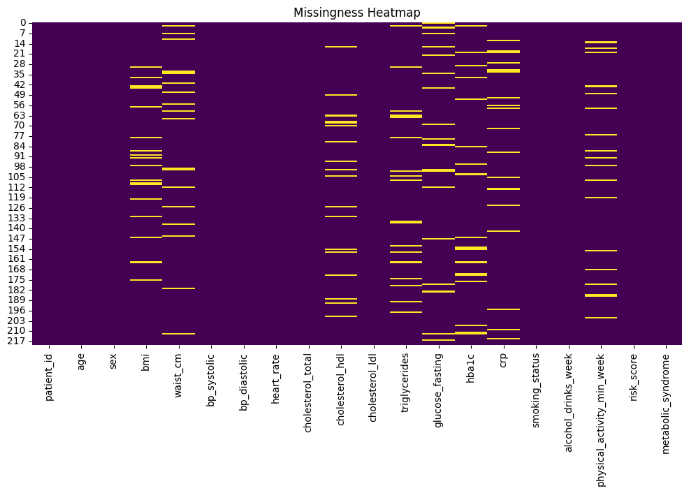

```python
#2.1.4: Create a missingness heatmap  on the boolean missingness matrix.

plt.figure(figsize=(12, 6))
sns.heatmap(df.isnull(), cbar=False, cmap='viridis')
plt.title('Missingness Heatmap')
plt.show()
```

The variables BME, Waist, cholestrol hdl, tryglycerides, fasting gllucose, hbac, crp and physical activity in week are the most affected variables issing 18 obsevations each totaling to 8.2% of missing data

```python
# 2.1.5: univariate summaries for all numeric variables

df.describe()
```

|  | age | bmi | waist_cm | bp_systolic | bp_diastolic | heart_rate | cholesterol_total | cholesterol_hdl | cholesterol_ldl | triglycerides | glucose_fasting | hba1c | crp | alcohol_drinks_week | physical_activity_min_week | risk_score | metabolic_syndrome |
| --- | --- | --- | --- | --- | --- | --- | --- | --- | --- | --- | --- | --- | --- | --- | --- | --- | --- |
| count | 220.000000 | 202.000000 | 202.000000 | 220.000000 | 220.000000 | 220.000000 | 220.000000 | 202.000000 | 220.000000 | 202.000000 | 202.000000 | 202.000000 | 202.000000 | 220.000000 | 202.000000 | 220.000000 | 220.00000 |
| mean | 52.409091 | 28.871287 | 139.034653 | 136.514091 | 86.504545 | 70.936364 | 196.874545 | 48.002970 | 115.548182 | 83.545050 | 105.610693 | 5.438317 | 2.020856 | 4.468182 | 192.787129 | 6.680909 | 0.50000 |
| std | 13.722824 | 11.280907 | 3.190360 | 57.619915 | 13.103904 | 11.960572 | 39.952441 | 13.344248 | 42.221077 | 58.220374 | 46.770429 | 0.628907 | 2.925588 | 2.150478 | 215.468342 | 3.417134 | 0.50114 |
| min | 18.000000 | 16.000000 | 123.200000 | 90.000000 | 55.000000 | 50.000000 | 81.800000 | 9.200000 | 40.000000 | 15.100000 | 60.000000 | 4.000000 | 0.070000 | 0.000000 | 8.000000 | 0.000000 | 0.00000 |
| 25% | 42.000000 | 23.550000 | 140.000000 | 116.000000 | 77.000000 | 62.000000 | 170.225000 | 39.075000 | 87.350000 | 44.125000 | 86.050000 | 5.042500 | 0.472500 | 3.000000 | 53.000000 | 4.575000 | 0.00000 |
| 50% | 52.000000 | 28.250000 | 140.000000 | 126.000000 | 86.000000 | 70.000000 | 196.250000 | 48.250000 | 115.200000 | 69.550000 | 100.750000 | 5.400000 | 1.000000 | 4.000000 | 108.000000 | 6.500000 | 0.50000 |
| 75% | 61.000000 | 31.275000 | 140.000000 | 139.000000 | 95.000000 | 80.000000 | 222.600000 | 56.475000 | 144.725000 | 107.175000 | 115.175000 | 5.875000 | 2.262500 | 6.000000 | 242.250000 | 8.625000 | 1.00000 |
| max | 85.000000 | 125.460000 | 140.000000 | 508.800000 | 120.000000 | 101.000000 | 306.000000 | 82.400000 | 220.300000 | 447.720000 | 442.560000 | 6.930000 | 28.690000 | 11.000000 | 1000.000000 | 20.300000 | 1.00000 |

2.2 **Task 2: Data Preprocessing Pipeline**

```python
#2.2.0:Create a copy for preprocessing
medical_clean = df.copy()
medical_clean.head()
```

|  | patient_id | age | sex | bmi | waist_cm | bp_systolic | bp_diastolic | heart_rate | cholesterol_total | cholesterol_hdl | cholesterol_ldl | triglycerides | glucose_fasting | hba1c | crp | smoking_status | alcohol_drinks_week | physical_activity_min_week | risk_score | metabolic_syndrome |
| --- | --- | --- | --- | --- | --- | --- | --- | --- | --- | --- | --- | --- | --- | --- | --- | --- | --- | --- | --- | --- |
| 0 | PT-001 | 59 | Male | 17.3 | 138.8 | 153.0 | 96 | 88 | 154.6 | 54.1 | 60.6 | 83.90 | NaN | 5.56 | 0.20 | Current | 5 | 145.0 | 11.8 | 0 |
| 1 | PT-002 | 37 | Female | 27.6 | 140.0 | 103.0 | 72 | 50 | 189.7 | 69.2 | 89.1 | 38.10 | 87.7 | 5.34 | 2.30 | Never | 2 | 87.0 | 0.3 | 0 |
| 2 | PT-003 | 54 | Female | 23.0 | NaN | 117.0 | 71 | 89 | 269.5 | 30.2 | 200.8 | NaN | 105.0 | NaN | 0.20 | Never | 6 | 268.0 | 9.1 | 1 |
| 3 | PT-004 | 51 | Female | 22.8 | 140.0 | 508.8 | 104 | 89 | 222.5 | 59.2 | 132.0 | 64.00 | NaN | 5.99 | 28.69 | Never | 6 | 45.0 | 11.5 | 0 |
| 4 | PT-005 | 43 | Female | 23.5 | 140.0 | 125.0 | 87 | 86 | 140.5 | 43.2 | 59.7 | 130.56 | 96.0 | 5.38 | 2.14 | Current | 6 | 177.0 | 7.4 | 1 |

```python
#2.2.1: Handling missing values(drop)
medical_clean = medical_clean.dropna()
print(f"\nRows after removing missing values: {len(medical_clean)}")
```

```
Rows after removing missing values: 113
```

**Rational for dropping missing values** Precision medicine requires identifying homogeneous patient subgroups for targeted interventions **Method Used**: Listwise deletion (dropping rows with missing values)